```r
library(rstudioapi)
library(dplyr)
```

```r
library(cluster)
library(ggplot2)
library(lubridate)
set.seed(7004)
main_dir<- dirname(dirname(rstudioapi::getSourceEditorContext()$path))
datadir<- paste0(main_dir,"/data")
clus_data_path<- paste0(datadir,"/data_c.csv")

clus_data<- read.csv(clus_data_path)
```

Besides time series modelling, we also do a clustering to identify cities (location) with similar air quality. We cluster them by using only the latest 1 year (2015-01-01 to 2015-12-31) of data, with the mean value of numerical variables (SO_2, NO_2, RSPM, SPM, PM_2.5) as the features.

```r
start_date<- ymd("2015-01-01")
rec_clus_data<- clus_data[clus_data$date > start_date, ]

### remove rows with missing location
rec_clus_data<- rec_clus_data[!is.na(rec_clus_data$location), ]

loc_data<- rec_clus_data %>% group_by(location) %>%
  summarise(mean_so2 = mean(so2, na.rm=TRUE),
            mean_no2 = mean(no2, na.rm=TRUE),
            mean_rspm = mean(rspm, na.rm=TRUE),
            mean_spm = mean(spm, na.rm=TRUE),
            mean_pm2_5 = mean(pm2_5, na.rm=TRUE)
  ) %>% data.frame()

head(loc_data)
```

```
##    location  mean_so2  mean_no2 mean_rspm mean_spm mean_pm2_5
## 1      Agra  3.689055 20.822761 180.28234      NaN        NaN
## 2 Ahmedabad 13.230435 20.847826  89.25217      NaN   28.63913
## 3    Aizawl  2.001890  8.385633  44.10208      NaN        NaN
## 4     Akola  7.247191  8.378277 127.19476      NaN        NaN
## 5 Alappuzha  2.000000  5.000000  45.33613      NaN        NaN
## 6 Allahabad  3.608511 28.486692 250.65399      NaN        NaN
```

Find and impute missing values

```r
num_loc = nrow(loc_data)

for (col in colnames(loc_data) ){
  num_na<- sum(is.na(loc_data[col]))
  perc_na<- round(100*num_na/num_loc, digits=2)
  print(paste(col, num_na, perc_na))
}
```

```
## [1] "location 0 0"
## [1] "mean_so2 4 1.57"
## [1] "mean_no2 3 1.18"
## [1] "mean_rspm 0 0"
## [1] "mean_spm 254 100"
## [1] "mean_pm2_5 191 75.2"
```

We see that SPM (100% missing) and PM2.5 (75.2%) have very large amount of missing values. We can only drop these features as imputing them will introduce large bias in the clustering model. For SO_2 and NO_2, we will impute using mean value.

```r
loc_data$mean_so2[is.na(loc_data$mean_so2)]= mean(loc_data$mean_so2, na.rm = TRUE)
loc_data$mean_no2[is.na(loc_data$mean_no2)]= mean(loc_data$mean_no2, na.rm = TRUE)

#### set location as row names
rownames(loc_data)<- loc_data$location

#### drop unnecessary columns
clean_loc_data<- loc_data %>% select(-c(mean_spm, mean_pm2_5, location))

head(clean_loc_data)
```

```
##            mean_so2  mean_no2 mean_rspm
## Agra       3.689055 20.822761 180.28234
## Ahmedabad 13.230435 20.847826  89.25217
## Aizawl     2.001890  8.385633  44.10208
## Akola      7.247191  8.378277 127.19476
## Alappuzha  2.000000  5.000000  45.33613
## Allahabad  3.608511 28.486692 250.65399
```

Next, we scale the features so that their magnitude are of the same order.

```r
scaled_loc_data<- clean_loc_data
for (mean_col in c("mean_so2", "mean_no2", "mean_rspm")){
 scaled_loc_data[mean_col]<- scale(scaled_loc_data[mean_col], center=TRUE, scale=TRUE)
}
```

Now we can do clustering. We use the elbow method to obtain a suitable number of clusters, k.

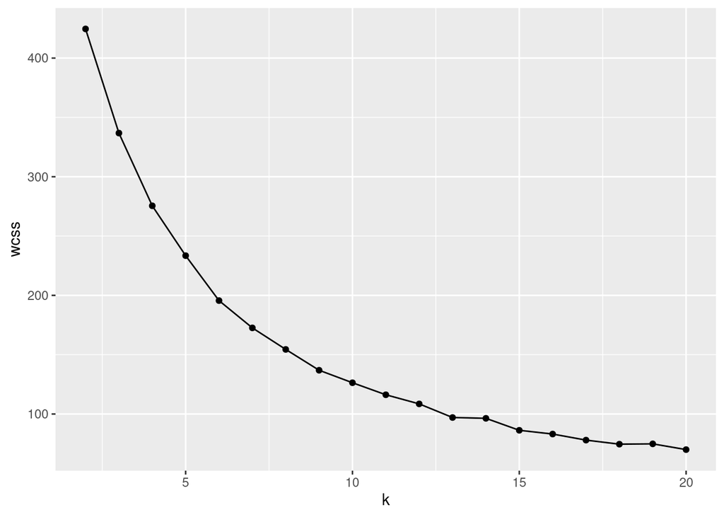

```r
max_k<- 20
wcss<- rep(NA, max_k-1)

for (k in c(2:max_k)){
  k_clus<- kmeans(scaled_loc_data, centers = k, nstart = 10)
  wcss[k-1]<- k_clus$tot.withinss
}

wcss_df<- data.frame(k=c(2:max_k), wcss = wcss)
wcss_fig<- wcss_df %>% ggplot(aes(x=k, y=wcss)) +
  geom_line() + geom_point()

print(wcss_fig)
```

Here, we see that at around k=8 the total sumsquared decreases slowly. Thus we will pick optimal k as 8 to do the clustering.

```r
best_k<- 8

clus_loc<- kmeans(scaled_loc_data, centers = scaled_loc_data[1:best_k,], nstart = 10)
clus_grp<- data.frame(clus_loc$cluster) %>% setNames("cluster")
merged_res<- merge(clean_loc_data, clus_grp, by ='row.names', all=TRUE)
merged_res$cluster<- as.factor(merged_res$cluster)

### center of each cluster
center_data<- merged_res %>% group_by(cluster) %>%
  summarise(num_city = n(),
            cen_mean_so2 = mean(mean_so2, na.rm=TRUE),
            cen_mean_no2 = mean(mean_no2, na.rm=TRUE),
            cen_mean_rspm = mean(mean_rspm, na.rm=TRUE),
  ) %>% data.frame()

print(center_data)
```

```
##   cluster num_city cen_mean_so2 cen_mean_no2 cen_mean_rspm
## 1       1       24     8.375138     24.87456     147.06674
## 2       2       36    13.643467     21.64344      85.97458
## 3       3       32     6.353506     25.07242      70.44578
## 4       4       57     4.864980     14.48268      98.23663
## 5       5       60     3.959786     10.03803      50.47906
## 6       6       12    12.169472     36.11782     209.11197
## 7       7       14    25.603259     31.94829     138.60601
## 8       8       19    15.276456     51.08625     109.78509
```

The above table shows the centroid for each cluster. To better visualise the difference among the clusters, we can plot the box plot of each features for the clusters:

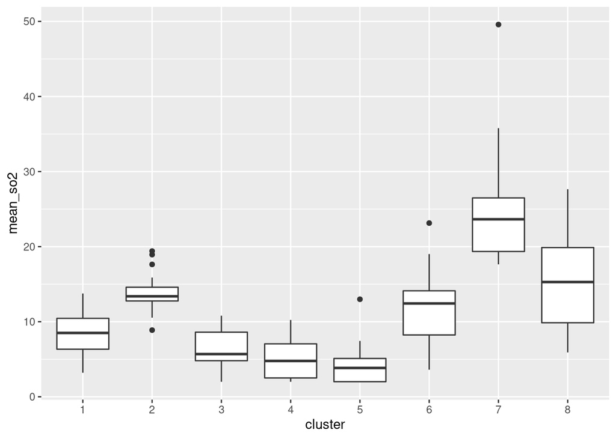

```r
clus_vis_so2<- merged_res %>% ggplot(aes(x=cluster, y=mean_so2)) +
  geom_boxplot()
print(clus_vis_so2)
```

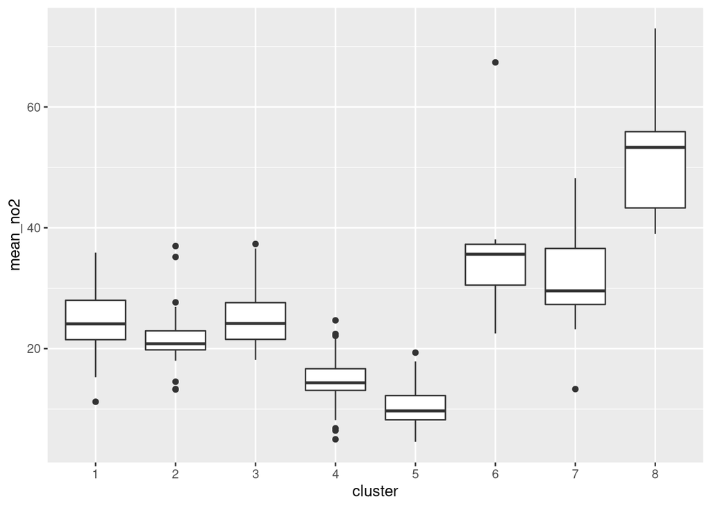

```r
clus_vis_no2<- merged_res %>% ggplot(aes(x=cluster, y=mean_no2)) +
  geom_boxplot()
print(clus_vis_no2)
```

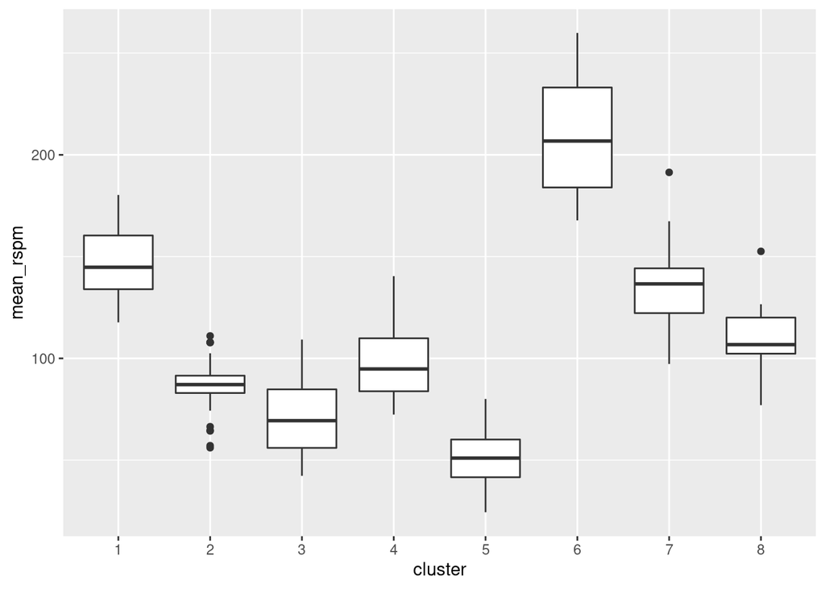

```r
clus_vis_rspm<- merged_res %>% ggplot(aes(x=cluster, y=mean_rspm)) +
  geom_boxplot()
print(clus_vis_rspm)
```

From the plot, we see that cities in cluster 6, 7 and 8 have high values in all 3 features, which represents low air quality. Interestingly, these clusters have significantly high value in exactly 1 of the feature: cluster 6 is high in RSPM, cluster 7 in SO2 and cluster 8 in NO2. For the others, cities in cluster 5 have the best air quality with lowest value in all 3 features. Cluster 2, 3, 4 have moderate value in all 3 features while cluster 1 has moderate value in SO2 and NO2 but with high RSPM.